# Customizing sampler choices (N-mixture example)

Perry de Valpine

September 2019

2. Customize sampler choices:
   - Try blocking correlated parameters.
   - Try sampling standard deviations on a log scale.
   - Try slice samplers instead of Metropolis-Hastings.
   - Try multiple samplers for slow-mixing parameters.

# Example: N-mixture model

- From AHM (Kéry & Royle), Chapter 6, Section 6.4
- A simulated example
- M = 100 sites
- J = 3 sampling occasions
- vegHt = vegetation height, covariate for abundance
- wind = wind speed, covariate for detection

# Simulation code from AHM

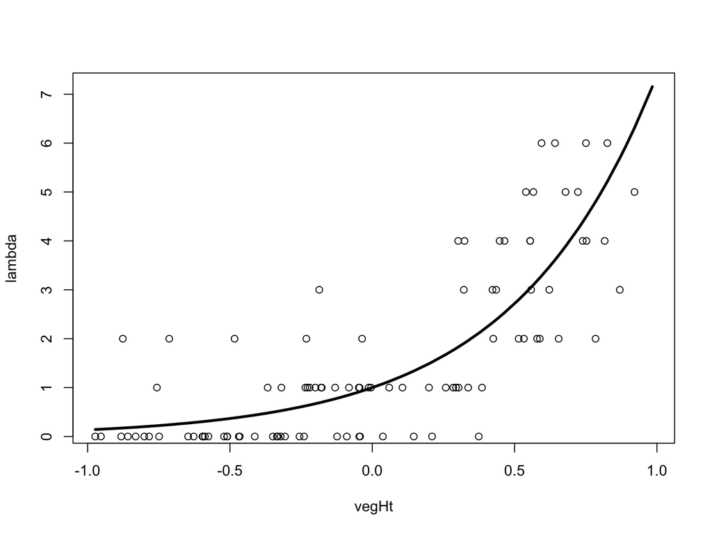

```r
## From AHM Chapter 6, section 6.4
## Adaptation for NIMBLE by Jacob Levine and Perry de Valpine

# 6.4 A slightly more complex N-mixture model with covariates
# ------------------------------------------------------------------------
DO_PLOT <- TRUE
# Choose sample sizes and prepare obs. data array y
set.seed(1)                   # So we all get same data set
M <- 100                      # Number of sites
J <- 3                        # Number of repeated abundance measurements
C <- matrix(NA, nrow = M, ncol = J) # to contain the observed data

# Create a covariate called vegHt
vegHt <- sort(runif(M, -1, 1)) # sort for graphical convenience

# Choose parameter values for abundance model and compute lambda
beta0 <- 0                    # Log-scale intercept
beta1 <- 2                    # Log-scale slope for vegHt
lambda <- exp(beta0 + beta1 * vegHt) # Expected abundance
if(DO_PLOT) plot(vegHt, lambda, type = "l", lwd = 3)  # Expected abundance

# Draw local abundance and look at data so far
N <- rpois(M, lambda)
if(DO_PLOT) points(vegHt, N)              # Add realized abundance to plot
```

```r
if(DO_PLOT) table(N)
```

```
## N
##  0  1  2  3  4  5  6  8  9
## 35 24 12  7  9  5  4  3  1
```

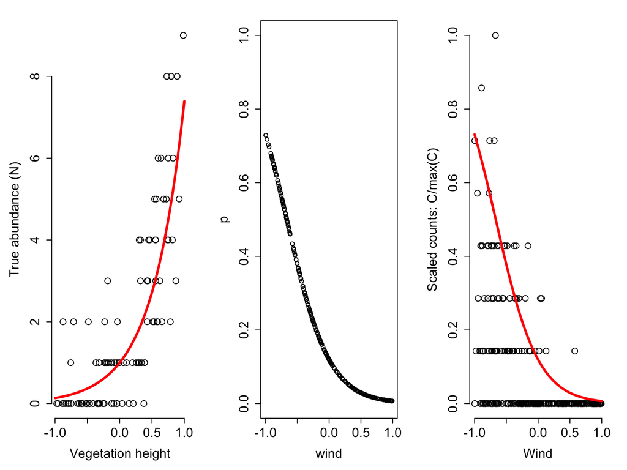

```r
# Plot the true system state (Fig. 6�2, left)
if(DO_PLOT) {
    par(mfrow = c(1, 3), mar = c(5,5,2,2), cex.axis = 1.5, cex.lab = 1.5)
    plot(vegHt, N, xlab="Vegetation height", ylab="True abundance (N)", frame = F, cex = 1.5)
    lines(seq(-1,1,,100), exp(beta0 + beta1* seq(-1,1,,100)), lwd=3, col = "red")
}

# Create a covariate called wind
wind <- array(runif(M * J, -1, 1), dim = c(M, J))

# Choose parameter values for measurement error model and compute detectability
alpha0 <- -2                        # Logit-scale intercept
alpha1 <- -3                        # Logit-scale slope for wind
p <- plogis(alpha0 + alpha1 * wind) # Detection probability
if(DO_PLOT) plot(p ~ wind, ylim = c(0,1))       # Look at relationship

# Take J = 3 abundance measurements at each site
for(j in 1:J) {
  C[,j] <- rbinom(M, N, p[,j])
}

# Plot observed data and effect of wind on det. probability (Fig. 6�2, middle)
if(DO_PLOT) {
    plot(wind, C/max(C), xlab="Wind", ylab="Scaled counts: C/max(C)", frame = F, cex = 1.5)
    lines(seq(-1,1,,100), plogis(alpha0 + alpha1*seq(-1,1,,100)), lwd=3, col="red")
}
```

```r
# Expected (lambda) and realized abundance (N) and measurements (C)
cbind(lambda=round(lambda,2), N=N, C1=C[,1], C2=C[,2], C3=C[,3])
```

```
##        lambda N C1 C2 C3
##   [1,]   0.14 0  0  0  0
##   [2,]   0.15 0  0  0  0
##   [3,]   0.17 0  0  0  0
##   [4,]   0.17 2  1  0  0
##   [5,]   0.18 0  0  0  0
##   [6,]   0.19 0  0  0  0
##   [7,]   0.20 0  0  0  0
##   [8,]   0.21 0  0  0  0
##   [9,]   0.22 1  1  1  1
##  [10,]   0.22 0  0  0  0
##  [11,]   0.24 2  0  1  0
##  [12,]   0.27 0  0  0  0
##  [13,]   0.29 0  0  0  0
##  [14,]   0.30 0  0  0  0
```

[output cut: 86 more lines]

```r
# Create factors
time <- matrix(rep(as.character(1:J), M), ncol = J, byrow = TRUE)
hab <- c(rep("A", 33), rep("B", 33), rep("C", 34))  # assumes M = 100

# Bundle data
win.data <- list(C = C, M = nrow(C), J = ncol(C), wind = wind, vegHt = vegHt, hab = as.numeric(factor(hab)), XvegHt = seq(-1, 1,, 100), Xwind = seq(-1, 1,,100) )
str(win.data)
```

```
## List of 8
##  $ C     : int [1:100, 1:3] 0 0 0 1 0 0 0 0 1 0 ...
##  $ M     : int 100
##  $ J     : int 3
##  $ wind  : num [1:100, 1:3] -0.465 -0.5627 0.0336 -0.4621 -0.6377 ...
##  $ vegHt : num [1:100] -0.973 -0.953 -0.882 -0.876 -0.859 ...
##  $ hab   : num [1:100] 1 1 1 1 1 1 1 1 1 1 ...
##  $ XvegHt: num [1:100] -1 -0.98 -0.96 -0.939 -0.919 ...
##  $ Xwind : num [1:100] -1 -0.98 -0.96 -0.939 -0.919 ...
```

# Model code

```r
require(nimble)
# Specify model in BUGS language
# This corresponds to "model2.txt" in original AHM code.
Section6p4_code <- nimbleCode( {
    # Priors
    for(k in 1:3) {                # Loop over 3 levels of hab or time factors
      alpha0[k] ~ dunif(-10, 10) # Detection intercepts
      alpha1[k] ~ dunif(-10, 10) # Detection slopes
      beta0[k] ~ dunif(-10, 10)  # Abundance intercepts
      beta1[k] ~ dunif(-10, 10)  # Abundance slopes
    }

    # Likelihood
    # Ecological model for true abundance
    for (i in 1:M){
      N[i] ~ dpois(lambda[i])
      log(lambda[i]) <- beta0[hab[i]] + beta1[hab[i]] * vegHt[i]
      # Some intermediate derived quantities
      critical[i] <- step(2-N[i])# yields 1 whenever N is 2 or less
      z[i] <- step(N[i]-0.5)     # Indicator for occupied site
      # Observation model for replicated counts
      for (j in 1:J){
        C[i,j] ~ dbin(p[i,j], N[i])
        logit(p[i,j]) <- alpha0[j] + alpha1[j] * wind[i,j]
        }
    }

    # Derived quantities; unnececssary when running for inference purpose
    Nocc <- sum(z[1:100])         # Number of occupied sites among sample of M
    Ntotal <- sum(N[1:100])       # Total population size at M sites combined
    Nhab[1] <- sum(N[1:33])  # Total abundance for sites in hab A
    Nhab[2] <- sum(N[34:66]) # Total abundance for sites in hab B
    Nhab[3] <- sum(N[67:100])# Total abundance for sites in hab C
    # We omit these derived quantities because they are direct calculations
    # that can be done after the MCMC.
    # for(k in 1:100){         # Predictions of lambda and p ...
    #   for(level in 1:3){    #    ... for each level of hab and time factors
    #     lam.pred[k, level] <- exp(beta0[level] + beta1[level] * XvegHt[k])
    #     logit(p.pred[k, level]) <- alpha0[level] + alpha1[level] * Xwind[k]
    #     }
    #   }
    N.critical <- sum(critical[1:100]) # Number of populations with critical size
  })
```

# Create inits and build model

```r
# Initial values
Nst <- apply(C, 1, max)+1   # Important to give good inits for latent N
inits <- function() list(N = Nst,
                         alpha0 = rnorm(3),
                         alpha1 = rnorm(3),
                         beta0 = rnorm(3),
                         beta1 = rnorm(3))

# Parameters monitored
params <- c("alpha0", "alpha1", "beta0", "beta1", "Nocc", "Ntotal", "Nhab", "N.critical")

Nmix_model <- nimbleModel(Section6p4_code,
                          constants = win.data,
                          inits = inits())
```

```
## defining model...
```

```
## Detected C as data within 'constants'.
```

```
## Adding C as data for building model.
```

```
## building model...
```

```
## setting data and initial values...
```

```
## running calculate on model (any error reports that follow may simply reflect missing values in model variables) ...
## checking model sizes and dimensions...
## model building finished.
```

# Run MCMC with default sampler configuration:

```r
samples_default <- nimbleMCMC(Section6p4_code,
                              inits = inits,
                              constants = win.data,
                              niter = 20000,
                              nburnin = 2000)
```

```
## defining model...
```

```
## Detected C as data within 'constants'.
```

```
## Adding C as data for building model.
```

```
## building model...
```

```
## setting data and initial values...
```

```
## running calculate on model (any error reports that follow may simply reflect missing values in model variables) ...
## checking model sizes and dimensions...
## checking model calculations...
## model building finished.
## compiling... this may take a minute. Use 'showCompilerOutput = TRUE' to see C++ compilation details.
## compilation finished.
## running chain 1...
```

```
## |-------------|-------------|-------------|-------------|
## |-------------------------------------------------------|
```

We are interested in the actual parameters (alphas, betas), not derived values (N’s).

# Thinking about sampler configuration

1. What parameters mix most slowly?

```r
require(coda)
effectiveSize(samples_default)
```

```
## alpha0[1] alpha0[2] alpha0[3] alpha1[1] alpha1[2] alpha1[3]  beta0[1]
##  803.4429  804.8790 1031.1229  658.7096  692.6722  890.3772  110.1446
##  beta0[2]  beta0[3]  beta1[1]  beta1[2]  beta1[3]
## 1503.2823  100.8795  116.7041 1588.7736   96.3159
```

We see the beta0[1], beta0[3], and beta1[3] mix most slowly. What does that look like in a trace plot?

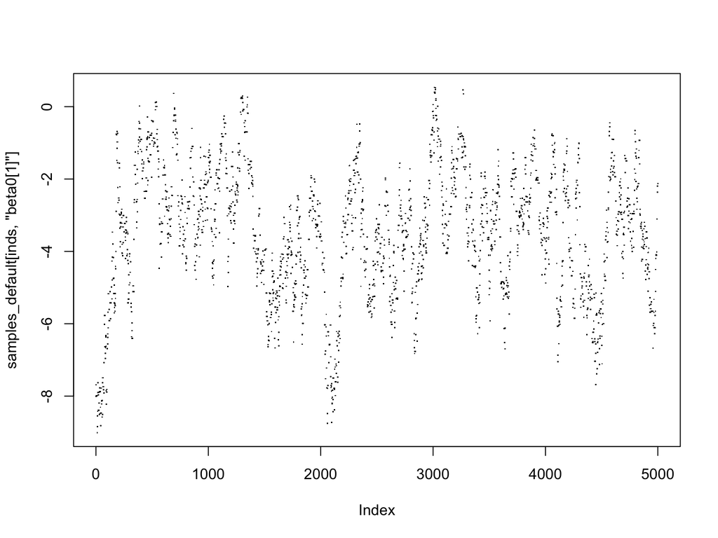

```r
inds <- 1001:6000 ## look at 5000 iterations
plot(samples_default[inds, 'beta0[1]'], pch = '.')
```

2. Are there posterior correlations?

```r
cor(samples_default)
```

```
##              alpha0[1]   alpha0[2]   alpha0[3]    alpha1[1]    alpha1[2]
## alpha0[1]  1.000000000  0.07136903  0.12184588  0.645444808 -0.042839177
## alpha0[2]  0.071369034  1.00000000  0.09156243 -0.063794489  0.704391031
## alpha0[3]  0.121845881  0.09156243  1.00000000 -0.056194664 -0.035749283
## alpha1[1]  0.645444808 -0.06379449 -0.05619466  1.000000000  0.080245191
## alpha1[2] -0.042839177  0.70439103 -0.03574928  0.080245191  1.000000000
## alpha1[3] -0.058790358 -0.03865540  0.59391084  0.056244615  0.041998337
## beta0[1]  -0.018548856 -0.03468636 -0.03323765  0.032991610  0.009184804
## beta0[2]  -0.106306388 -0.07189663 -0.09295335  0.030974753  0.046911119
## beta0[3]  -0.136876180 -0.11205858 -0.03628397 -0.002019018 -0.045390022
## beta1[1]   0.010603194 -0.01909840 -0.01711514  0.033683757  0.003597744
## beta1[2]  -0.008705427 -0.01007346 -0.01564507  0.036053241  0.014982985
## beta1[3]   0.095200559  0.07448043 -0.01306692  0.054311262  0.072235910
##              alpha1[3]     beta0[1]      beta0[2]     beta0[3]
## alpha0[1] -0.058790358 -0.018548856 -0.1063063885 -0.136876180
## alpha0[2] -0.038655399 -0.034686363 -0.0718966347 -0.112058577
## alpha0[3]  0.593910842 -0.033237649 -0.0929533459 -0.036283970
## alpha1[1]  0.056244615  0.032991610  0.0309747533 -0.002019018
## alpha1[2]  0.041998337  0.009184804  0.0469111188 -0.045390022
## alpha1[3]  1.000000000  0.027637366  0.0526886490  0.075697338
## beta0[1]   0.027637366  1.000000000  0.0104988024  0.046784221
## beta0[2]   0.052688649  0.010498802  1.0000000000  0.060058421
## beta0[3]   0.075697338  0.046784221  0.0600584206  1.000000000
## beta1[1]   0.026732153  0.954441167  0.0003372739  0.046399260
## beta1[2]   0.005362312 -0.002098566 -0.4885638058 -0.009300202
## beta1[3]  -0.040713744 -0.035338200 -0.0298098039 -0.964916057
##                beta1[1]     beta1[2]    beta1[3]
## alpha0[1]  0.0106031935 -0.008705427  0.09520056
## alpha0[2] -0.0190984023 -0.010073465  0.07448043
## alpha0[3] -0.0171151419 -0.015645070 -0.01306692
## alpha1[1]  0.0336837567  0.036053241  0.05431126
## alpha1[2]  0.0035977436  0.014982985  0.07223591
## alpha1[3]  0.0267321526  0.005362312 -0.04071374
## beta0[1]   0.9544411669 -0.002098566 -0.03533820
## beta0[2]   0.0003372739 -0.488563806 -0.02980980
## beta0[3]   0.0463992600 -0.009300202 -0.96491606
## beta1[1]   1.0000000000 -0.002651693 -0.03887468
## beta1[2]  -0.0026516931  1.000000000  0.01755155
## beta1[3]  -0.0388746761  0.017551546  1.00000000
```

There are some strong correlations among slope-intercept pairs.

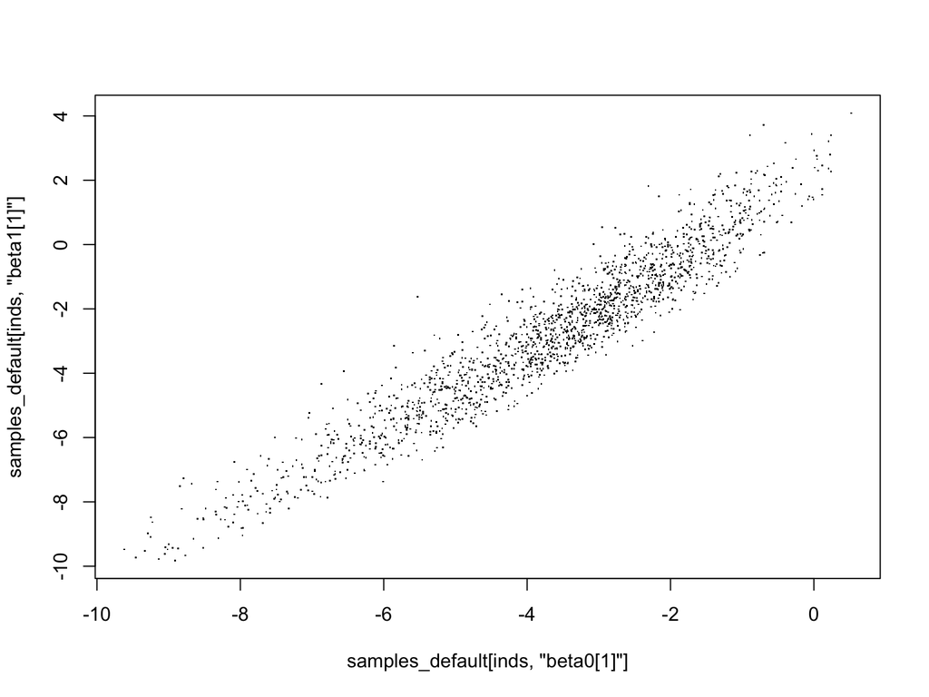

```r
inds <- seq(1, nrow(samples_default), by = 10)
plot(samples_default[inds, 'beta0[1]'], samples_default[inds, 'beta1[1]'], pch = '.')
```

Let’s set up block samplers on slope-intercept pairs.

# Customizing sampler configuration

We will

1. Build the model.
2. Make a default sampler configuration and look at the sampler assignments.
3. Remove samplers we don’t need.
4. Add block samplers that we want to try.
5. Build the MCMC, compile and run.
6. Look at effective sample size and computation time.

# Build the model

```r
Nmix_model <- nimbleModel(Section6p4_code,
                          constants = win.data,
                          inits = inits())
```

```
## defining model...
```

```
## Detected C as data within 'constants'.
```

```
## Adding C as data for building model.
```

```
## building model...
```

```
## setting data and initial values...
```

```
## running calculate on model (any error reports that follow may simply reflect missing values in model variables) ...
## checking model sizes and dimensions...
## model building finished.
```

# Make default sampler configuration

```r
MCMCconf <- configureMCMC(Nmix_model)
MCMCconf$printSamplers()
```

```
## [1]   RW sampler: alpha0[1]
## [2]   RW sampler: alpha0[2]
## [3]   RW sampler: alpha0[3]
## [4]   RW sampler: alpha1[1]
## [5]   RW sampler: alpha1[2]
## [6]   RW sampler: alpha1[3]
## [7]   RW sampler: beta0[1]
## [8]   RW sampler: beta0[2]
## [9]   RW sampler: beta0[3]
## [10]  RW sampler: beta1[1]
## [11]  RW sampler: beta1[2]
## [12]  RW sampler: beta1[3]
## [13]  slice sampler: N[1]
## [14]  slice sampler: N[2]
## [15]  slice sampler: N[3]
```

[output cut: 97 more lines]

# Remove samplers we don’t want

```r
MCMCconf$removeSamplers('alpha0')
MCMCconf$removeSamplers('alpha1')
MCMCconf$removeSamplers('beta0')
MCMCconf$removeSamplers('beta1')
MCMCconf$printSamplers()
```

```
## [1]   slice sampler: N[1]
## [2]   slice sampler: N[2]
## [3]   slice sampler: N[3]
## [4]   slice sampler: N[4]
## [5]   slice sampler: N[5]
## [6]   slice sampler: N[6]
## [7]   slice sampler: N[7]
## [8]   slice sampler: N[8]
## [9]   slice sampler: N[9]
## [10]  slice sampler: N[10]
## [11]  slice sampler: N[11]
## [12]  slice sampler: N[12]
## [13]  slice sampler: N[13]
## [14]  slice sampler: N[14]
## [15]  slice sampler: N[15]
```

[output cut: 85 more lines]

# Add new samplers

```r
MCMCconf$addSampler(target = c('beta0[1]', 'beta1[1]'), type = "RW_block")
```

```
## Note: Assigning an RW_block sampler to nodes with very different scales can result in low MCMC efficiency.  If all nodes assigned to RW_block are not on a similar scale, we recommend providing an informed value for the "propCov" control list argument, or using the AFSS sampler instead.
```

```r
MCMCconf$addSampler(target = c('beta0[2]', 'beta1[2]'), type = "RW_block")
```

```
## Note: Assigning an RW_block sampler to nodes with very different scales can result in low MCMC efficiency.  If all nodes assigned to RW_block are not on a similar scale, we recommend providing an informed value for the "propCov" control list argument, or using the AFSS sampler instead.
```

```r
MCMCconf$addSampler(target = c('beta0[3]', 'beta1[3]'), type = "RW_block")
```

```
## Note: Assigning an RW_block sampler to nodes with very different scales can result in low MCMC efficiency.  If all nodes assigned to RW_block are not on a similar scale, we recommend providing an informed value for the "propCov" control list argument, or using the AFSS sampler instead.
```

```r
MCMCconf$addSampler(target = c('alpha0[1]', 'alpha1[1]'), type = "RW_block")
```

```
## Note: Assigning an RW_block sampler to nodes with very different scales can result in low MCMC efficiency.  If all nodes assigned to RW_block are not on a similar scale, we recommend providing an informed value for the "propCov" control list argument, or using the AFSS sampler instead.
```

```r
MCMCconf$addSampler(target = c('alpha0[2]', 'alpha1[2]'), type = "RW_block")
```

```
## Note: Assigning an RW_block sampler to nodes with very different scales can result in low MCMC efficiency.  If all nodes assigned to RW_block are not on a similar scale, we recommend providing an informed value for the "propCov" control list argument, or using the AFSS sampler instead.
```

```r
MCMCconf$addSampler(target = c('alpha0[3]', 'alpha1[3]'), type = "RW_block")
```

```
## Note: Assigning an RW_block sampler to nodes with very different scales can result in low MCMC efficiency.  If all nodes assigned to RW_block are not on a similar scale, we recommend providing an informed value for the "propCov" control list argument, or using the AFSS sampler instead.
```

```r
MCMCconf$printSamplers()
```

```
## [1]   slice sampler: N[1]
## [2]   slice sampler: N[2]
## [3]   slice sampler: N[3]
## [4]   slice sampler: N[4]
## [5]   slice sampler: N[5]
## [6]   slice sampler: N[6]
## [7]   slice sampler: N[7]
## [8]   slice sampler: N[8]
## [9]   slice sampler: N[9]
## [10]  slice sampler: N[10]
## [11]  slice sampler: N[11]
## [12]  slice sampler: N[12]
## [13]  slice sampler: N[13]
## [14]  slice sampler: N[14]
## [15]  slice sampler: N[15]
```

[output cut: 91 more lines]

(We could get these target node names from the model to make this more generic.)

# Build, compile and run

```r
MCMC <- buildMCMC(MCMCconf)
compiled <- compileNimble(Nmix_model, MCMC) ## illustrate compiling both in one step
```

```
## compiling... this may take a minute. Use 'showCompilerOutput = TRUE' to see C++ compilation details.
```

```
## compilation finished.
```

```r
new_samples <- runMCMC(compiled$MCMC, niter = 20000, nburnin = 2000)
```

```
## running chain 1...
```

```
## |-------------|-------------|-------------|-------------|
## |-------------------------------------------------------|
```

# Look at effective sample size

```r
effectiveSize(new_samples)
```

```
## alpha0[1] alpha0[2] alpha0[3] alpha1[1] alpha1[2] alpha1[3]  beta0[1]
##  1253.018  1749.794  1638.791  1094.874  1565.469  1436.359  1272.823
##  beta0[2]  beta0[3]  beta1[1]  beta1[2]  beta1[3]
##  1373.842  1143.224  1263.671  1270.362  1183.989
```

Wow, that looks better. Let’s make the sample trace plot as above:

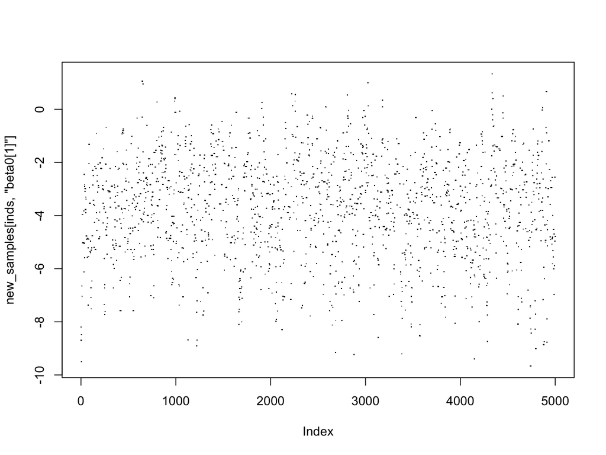

```r
inds <- 1001:6000
plot(new_samples[inds, 'beta0[1]'], pch = '.') ## much better!
```

**Was it worth the computational cost?**

# Automating the process of comparing MCMCs using `compareMCMCs`

1. Write functions to create any custom configurations of interest.
2. Build, compile and run through `compareMCMCs` for one or more cases.
   - `compareMCMCs` times multiple methods, including JAGS, and calculates comparison metrics.
   - Multiple MCMCs that use the same model can be run.
   - Multiple results can be combined.
   - figures and html showing comparison results can be generated.

# MCMC methods to compare

Let’s try the following methods:

- Blocking using automated factor slice sampler (AFSS)
- Blocking using random-walk block sampler
  - use 2 trials per iteration

# Function to create custom MCMC configurations

```r
configure_nimbleAFSS <- function(model) {
  MCMCconf <- configureMCMC(model)
  MCMCconf$removeSamplers('alpha0')
  MCMCconf$removeSamplers('alpha1')
  MCMCconf$removeSamplers('beta0')
  MCMCconf$removeSamplers('beta1')
  MCMCconf$addSampler(target = c('beta0[1]', 'beta1[1]'), type = "AF_slice")
  MCMCconf$addSampler(target = c('beta0[2]', 'beta1[2]'), type = "AF_slice")
  MCMCconf$addSampler(target = c('beta0[3]', 'beta1[3]'), type = "AF_slice")
  MCMCconf$addSampler(target = c('alpha0[1]', 'alpha1[1]'), type = "AF_slice")
  MCMCconf$addSampler(target = c('alpha0[2]', 'alpha1[2]'), type = "AF_slice")
  MCMCconf$addSampler(target = c('alpha0[3]', 'alpha1[3]'), type = "AF_slice")
  MCMCconf
}

configure_nimbleRWB <- function(model) {
  MCMCconf <- configureMCMC(model)
  MCMCconf$removeSamplers('alpha0')
  MCMCconf$removeSamplers('alpha1')
  MCMCconf$removeSamplers('beta0')
  MCMCconf$removeSamplers('beta1')
  MCMCconf$addSampler(target = c('beta0[1]', 'beta1[1]'), type = "RW_block", control = list(trials = 2))
  MCMCconf$addSampler(target = c('beta0[2]', 'beta1[2]'), type = "RW_block", control = list(trials = 2))
  MCMCconf$addSampler(target = c('beta0[3]', 'beta1[3]'), type = "RW_block", control = list(trials = 2))
  MCMCconf$addSampler(target = c('alpha0[1]', 'alpha1[1]'), type = "RW_block", control = list(trials = 2))
  MCMCconf$addSampler(target = c('alpha0[2]', 'alpha1[2]'), type = "RW_block", control = list(trials = 2))
  MCMCconf$addSampler(target = c('alpha0[3]', 'alpha1[3]'), type = "RW_block", control = list(trials = 2))
  MCMCconf
}
```

# Call `compareMCMCs`

```r
Nmix_results <- compareMCMCs(
  list(code = Section6p4_code,
       constants = win.data,
       inits = inits()),
  monitors = params,
  MCMCs = c("jags", "nimble", "nimbleAFSS", "nimbleRWB"),
  nimbleMCMCdefs = list(nimbleAFSS = configure_nimbleAFSS,
                        nimbleRWB = configure_nimbleRWB),
  MCMCcontrol = list(niter = 50000,
                     burnin = 5000)
)
```

```
## building nimble model...
```

```
## defining model...
```

```
## Detected C as data within 'constants'.
```

```
## Adding C as data for building model.
```

```
## building model...
```

```
## setting data and initial values...
```

```
## running calculate on model (any error reports that follow may simply reflect missing values in model variables) ...
## checking model sizes and dimensions...
## model building finished.
```

[output not shown]

```
## |-------------|-------------|-------------|-------------|
## |-------------------------------------------------------|
## |-------------|-------------|-------------|-------------|
## |-------------------------------------------------------|
## |-------------|-------------|-------------|-------------|
## |-------------------------------------------------------|
```

# Make HTML comparison pages

```r
make_MCMC_comparison_pages(Nmix_results,
                           dir = "Nmix_results_user",
                           modelName = "N-mixture")
```

Results with the slides are here.

Results if you run it yourself are here.

# Look at raw metrics

```r
combineMetrics(Nmix_results)
```

```
## $byParameter
##          MCMC  Parameter        mean      median         sd    CI95_low
## 1        jags  alpha0[1]  -1.4012407  -1.3840403  0.3952657  -2.2236523
## 2        jags  alpha0[2]  -1.9204032  -1.9008987  0.4228833  -2.7981429
## 3        jags  alpha0[3]  -2.0704291  -2.0522744  0.4425427  -2.9897736
## 4        jags  alpha1[1]  -3.6266291  -3.5636690  0.8169566  -5.3970763
## 5        jags  alpha1[2]  -4.7666076  -4.7101872  0.9340121  -6.7557270
## 6        jags  alpha1[3]  -4.9651251  -4.8925839  0.9557638  -7.0257937
## 7        jags   beta0[1]  -3.7376030  -3.5787563  1.8488538  -7.6658230
## 8        jags   beta0[2]  -0.3428760  -0.3303274  0.2813701  -0.9329905
## 9        jags   beta0[3]  -0.3319299  -0.3244434  0.4895472  -1.2963350
## 10       jags   beta1[1]  -2.8903446  -2.8287599  2.4886759  -7.8668085
## 11       jags   beta1[2]   2.0277199   2.0140953  1.2471498  -0.3879930
## 12       jags   beta1[3]   2.1991754   2.2007550  0.6590851   0.9140827
## 13       jags N.critical  76.3756667  77.0000000  2.4440419  71.0000000
```

[output cut: 139 more lines]